# M03-2: Data Visualization-Application Assignment

Author

Dia Kaewdee

Published

June 21, 2026

Preparation

```r
library(tidyverse)
library(ggrepel)
library(ggthemes)
library(scales)
library(plotly)
library(lattice)
library(GGally)
library(gt)
library(wooldridge)
```

Data

```r
# install.packages("wooldridge")

df <- attend

head(df)
```

```
  attend termGPA priGPA ACT final atndrte hwrte frosh soph missed     stndfnl
1     27    3.19   2.64  23    28  84.375 100.0     0    1      5  0.47268906
2     22    2.73   3.52  25    26  68.750  87.5     0    0     10  0.05252101
3     30    3.00   2.46  24    30  93.750  87.5     0    0      2  0.89285713
4     31    2.04   2.61  20    27  96.875 100.0     0    1      1  0.26260504
5     32    3.68   3.32  23    34 100.000 100.0     0    1      0  1.73319328
6     29    3.23   2.93  26    25  90.625 100.0     0    1      3 -0.15756303
```

```r
class(df)
```

```
[1] "data.frame"
```

```r
df <- as_tibble(df)

df
```

```
# A tibble: 680 × 11
   attend termGPA priGPA   ACT final atndrte hwrte frosh  soph missed stndfnl
    <int>   <dbl>  <dbl> <int> <int>   <dbl> <dbl> <int> <int>  <int>   <dbl>
 1     27    3.19   2.64    23    28    84.4 100       0     1      5  0.473
 2     22    2.73   3.52    25    26    68.8  87.5     0     0     10  0.0525
 3     30    3      2.46    24    30    93.8  87.5     0     0      2  0.893
 4     31    2.04   2.61    20    27    96.9 100       0     1      1  0.263
 5     32    3.68   3.32    23    34   100   100       0     1      0  1.73
 6     29    3.23   2.93    26    25    90.6 100       0     1      3 -0.158
 7     30    1.54   1.94    21    10    93.8  75       1     0      2 -3.31
 8     26    2      2.12    22    34    81.2 100       0     1      6  1.73
 9     24    2.25   2.06    24    26    75   100       1     0      8  0.0525
10     29    3      2.73    21    26    90.6 100       0     1      3  0.0525
# ℹ 670 more rows
```

Variable definitions:

- `attend`: classes attended out of 32
- `termGPA`: GPA for term
- `priGPA`: cumulative GPA prior to term
- `ACT`: ACT score
- `final`: final exam score
- `atndrte`: percent classes attended
- `hwrte`: percent homework turned in
- `frosh`: equals 1 if freshman
- `soph`: equals 1 if sophomore
- `missed`: number of classes missed
- `stndfnl`: standardized final exam score

# 1 Ex 1: GT Table

## 1.1 1.1 and 1.2 Create and decorate a GT table

```r
df %>%
  select(attend, termGPA, priGPA, ACT, final, atndrte, hwrte, frosh, soph) %>%
  slice_head(n = 12) %>%
  gt() %>%
  tab_header(
    title = "Preview of the Attend Dataset",
    subtitle = "Selected variables from the Wooldridge attend dataset"
  ) %>%
  cols_label(
    attend = "Classes Attended",
    termGPA = "Term GPA",
    priGPA = "Prior GPA",
    ACT = "ACT Score",
    final = "Final Exam Score",
    atndrte = "Attendance Rate",
    hwrte = "Homework Rate",
    frosh = "Freshman",
    soph = "Sophomore"
  ) %>%
  fmt_number(
    columns = c(termGPA, priGPA, final, atndrte, hwrte),
    decimals = 2
  ) %>%
  tab_spanner(
    label = "Academic Performance",
    columns = c(termGPA, priGPA, ACT, final)
  ) %>%
  tab_spanner(
    label = "Class Participation",
    columns = c(attend, atndrte, hwrte)
  ) %>%
  opt_row_striping() %>%
  tab_options(
    table.font.size = "small",
    heading.title.font.size = 18,
    heading.subtitle.font.size = 13
  )
```

Preview of the Attend Dataset

Selected variables from the Wooldridge attend dataset

[output not shown]

This GT table presents a clean preview of the dataset. I selected important variables related to attendance, homework, GPA, ACT scores, and student status. I used several GT functions to improve readability, including a title, subtitle, renamed columns, number formatting, column spanners, row striping, and table options.

# 2 Ex 2: Scatter Plot with ggplot2

## 2.1 2.1-2.4 Scatter plot of prior GPA and missed classes by sophomore status

```r
df_soph_relabeled <- df %>%
  mutate(
    soph = case_when(
      soph == 1 ~ "Sophomore",
      soph == 0 ~ "Non-Sophomore"
    ),
    soph = factor(soph)
  )

df_soph_relabeled
```

```
# A tibble: 680 × 11
   attend termGPA priGPA   ACT final atndrte hwrte frosh soph     missed stndfnl
    <int>   <dbl>  <dbl> <int> <int>   <dbl> <dbl> <int> <fct>     <int>   <dbl>
 1     27    3.19   2.64    23    28    84.4 100       0 Sophomo…      5  0.473
 2     22    2.73   3.52    25    26    68.8  87.5     0 Non-Sop…     10  0.0525
 3     30    3      2.46    24    30    93.8  87.5     0 Non-Sop…      2  0.893
 4     31    2.04   2.61    20    27    96.9 100       0 Sophomo…      1  0.263
 5     32    3.68   3.32    23    34   100   100       0 Sophomo…      0  1.73
 6     29    3.23   2.93    26    25    90.6 100       0 Sophomo…      3 -0.158
 7     30    1.54   1.94    21    10    93.8  75       1 Non-Sop…      2 -3.31
 8     26    2      2.12    22    34    81.2 100       0 Sophomo…      6  1.73
 9     24    2.25   2.06    24    26    75   100       1 Non-Sop…      8  0.0525
10     29    3      2.73    21    26    90.6 100       0 Sophomo…      3  0.0525
# ℹ 670 more rows
```

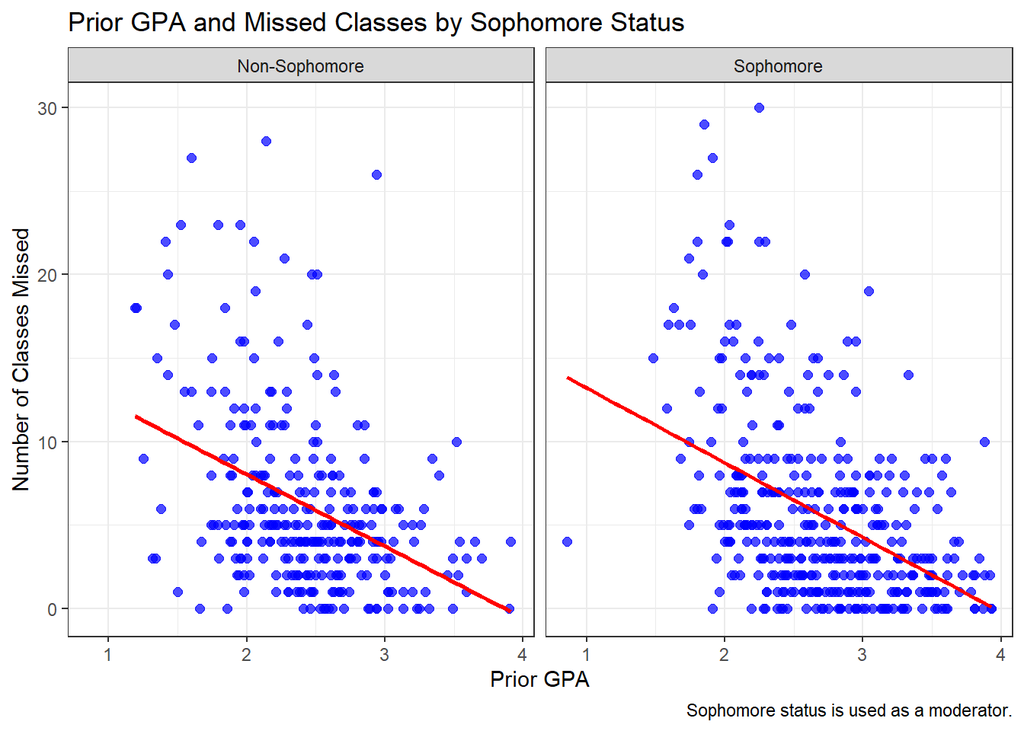

```r
ggplot(df_soph_relabeled, aes(x = priGPA, y = missed)) +
  geom_point(size = 2, color = "blue", alpha = 0.7) +
  geom_smooth(method = "lm", se = FALSE, color = "red") +
  facet_wrap(~ soph) +
  theme_bw() +
  labs(
    title = "Prior GPA and Missed Classes by Sophomore Status",
    x = "Prior GPA",
    y = "Number of Classes Missed",
    caption = "Sophomore status is used as a moderator."
  )
```

## 2.2 2.5 Insights

The chart suggests that students with higher prior GPAs tend to miss fewer classes overall. By splitting the data into sophomores and non-sophomores, we can also see whether this pattern differs between the two groups. The regression lines make it easier to spot and compare the overall trend for each group.

# 3 **Ex 3**: Understand barplots (dodge vs. stack vs. faceted)

## 3.1 3.1 Barplot for count of ACT scores

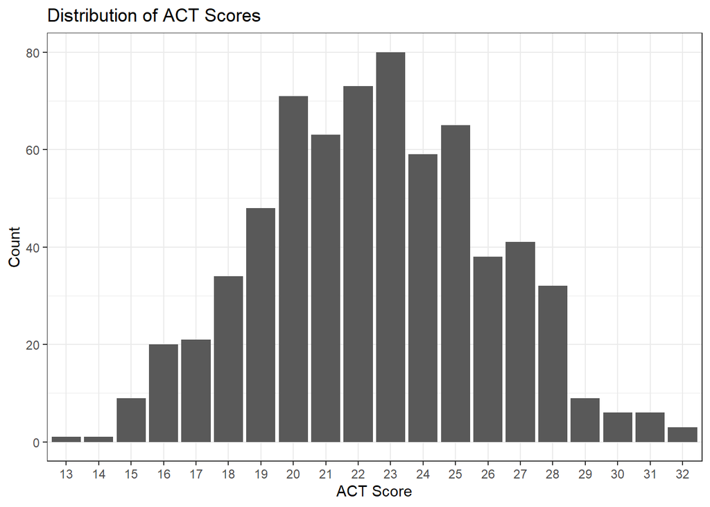

```r
ggplot(df, aes(x = factor(ACT))) +
  geom_bar() +
  theme_bw() +
  labs(
    title = "Distribution of ACT Scores",
    x = "ACT Score",
    y = "Count"
  )
```

This bar chart shows how ACT scores are distributed in the dataset. Most students have scores in the middle range, while fewer students have very low or very high scores. This creates a roughly bell-shaped (unimodal) distribution.

## 3.2 3.2 Dodged, stacked, and faceted bar charts using final score

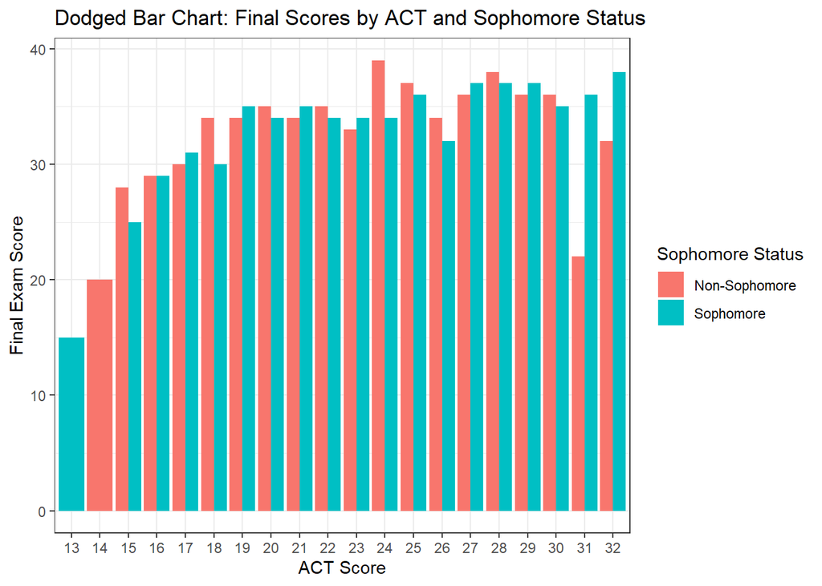

```r
ggplot(df_soph_relabeled, aes(x = factor(ACT), y = final, fill = soph)) +
  geom_col(position = "dodge") +
  theme_bw() +
  labs(
    title = "Dodged Bar Chart: Final Scores by ACT and Sophomore Status",
    x = "ACT Score",
    y = "Final Exam Score",
    fill = "Sophomore Status"
  )
```

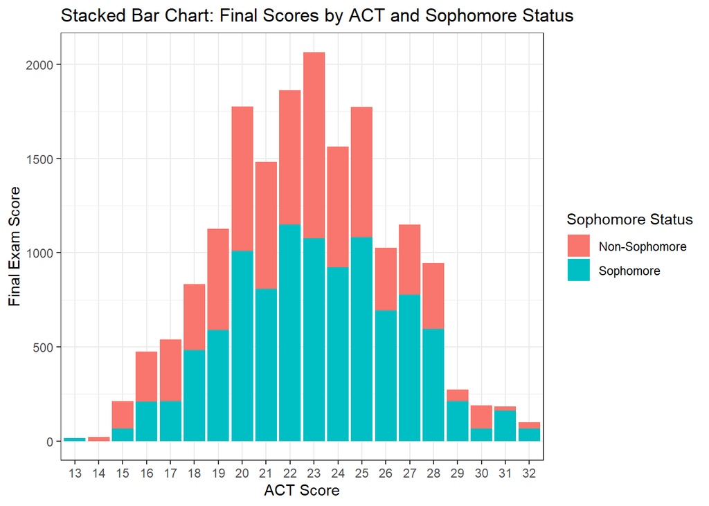

```r
ggplot(df_soph_relabeled, aes(x = factor(ACT), y = final, fill = soph)) +
  geom_col(position = "stack") +
  theme_bw() +
  labs(
    title = "Stacked Bar Chart: Final Scores by ACT and Sophomore Status",
    x = "ACT Score",
    y = "Final Exam Score",
    fill = "Sophomore Status"
  )
```

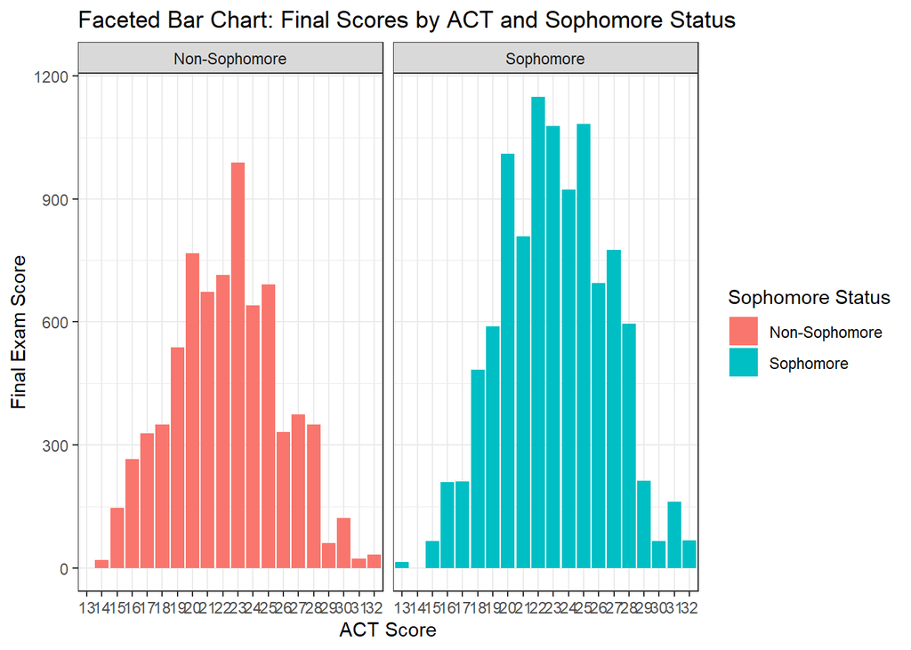

```r
ggplot(df_soph_relabeled, aes(x = factor(ACT), y = final, fill = soph)) +
  geom_col() +
  facet_wrap(~ soph) +
  theme_bw() +
  labs(
    title = "Faceted Bar Chart: Final Scores by ACT and Sophomore Status",
    x = "ACT Score",
    y = "Final Exam Score",
    fill = "Sophomore Status"
  )
```

## 3.3 3.3 Evaluation of the three charts

None of the three charts accurately show the relationship between ACT scores and final exam scores. The stacked bar chart is the most misleading because adding final exam scores together does not make sense. The dodged and faceted charts are easier to read, but they still use raw scores instead of averages. A scatterplot or a chart of average final exam scores would better represent the relationship.

# 4 Ex 4: Barplots with ACT Averages

## 4.1 4.1 Summarize average final exam score by ACT and sophomore status

```r
df_soph_relabeled_summarized <- df_soph_relabeled %>%
  group_by(soph, ACT) %>%
  summarise(
    final_avg = mean(final),
    n = n(),
    .groups = "drop"
  )

df_soph_relabeled_summarized
```

```
# A tibble: 38 × 4
   soph            ACT final_avg     n
   <fct>         <int>     <dbl> <int>
 1 Non-Sophomore    14      20       1
 2 Non-Sophomore    15      24.3     6
 3 Non-Sophomore    16      24.2    11
 4 Non-Sophomore    17      25.2    13
 5 Non-Sophomore    18      25      14
 6 Non-Sophomore    19      23.3    23
 7 Non-Sophomore    20      25.6    30
 8 Non-Sophomore    21      23.2    29
 9 Non-Sophomore    22      25.5    28
10 Non-Sophomore    23      26.0    38
# ℹ 28 more rows
```

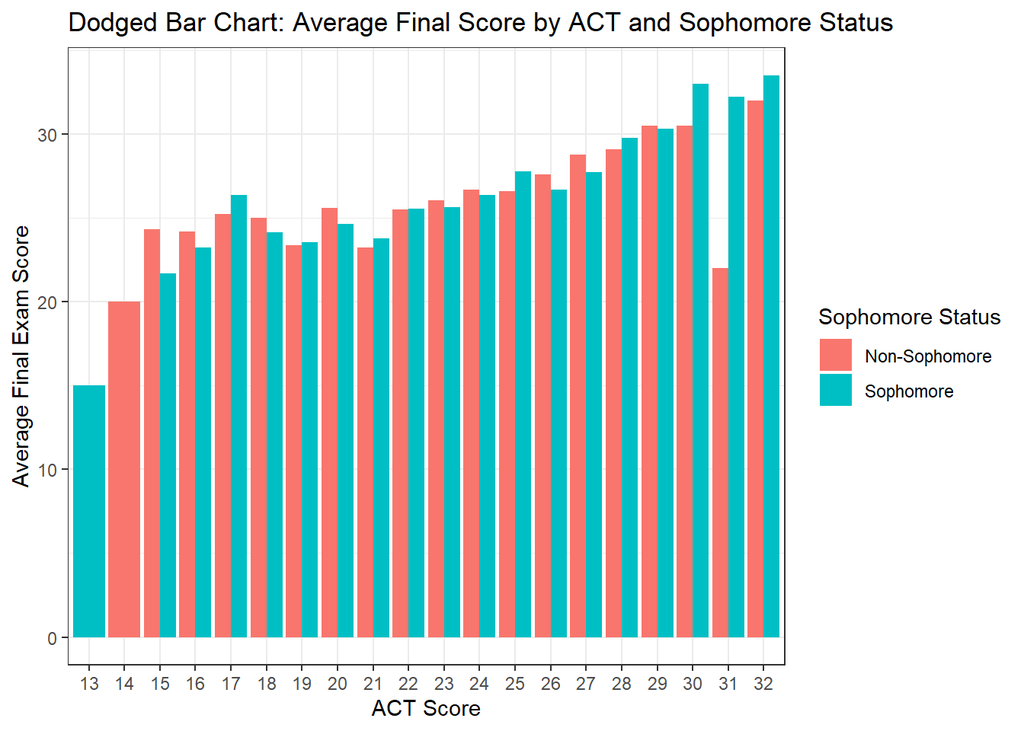

```r
ggplot(df_soph_relabeled_summarized, aes(x = factor(ACT), y = final_avg, fill = soph)) +
  geom_col(position = "dodge") +
  theme_bw() +
  labs(
    title = "Dodged Bar Chart: Average Final Score by ACT and Sophomore Status",
    x = "ACT Score",
    y = "Average Final Exam Score",
    fill = "Sophomore Status"
  )
```

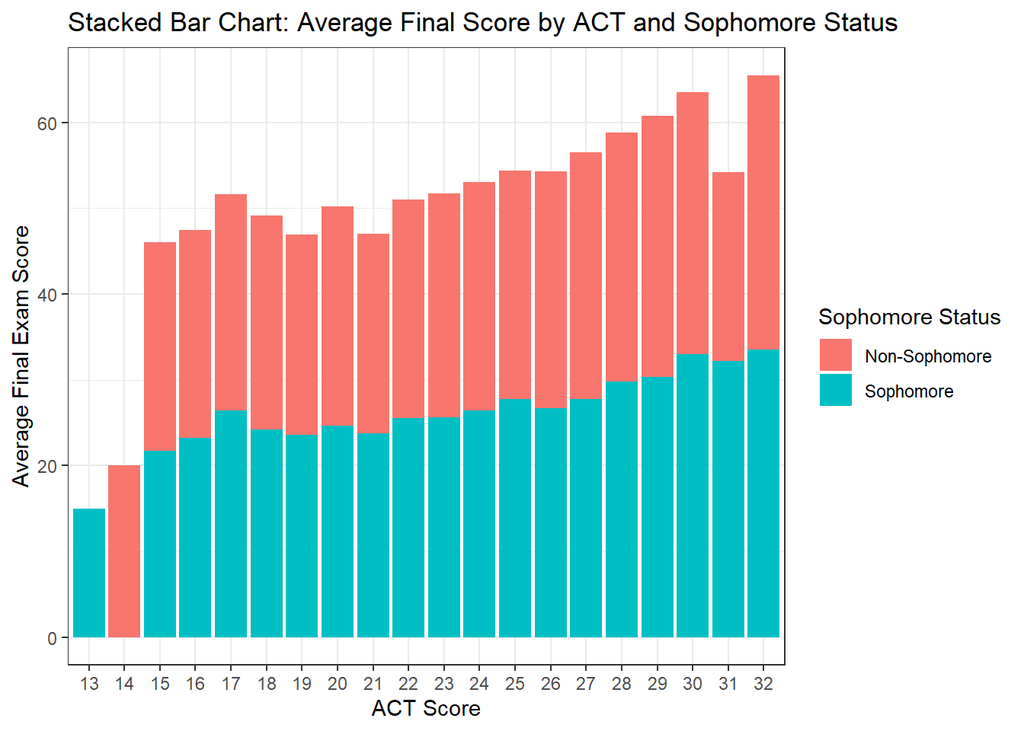

```r
ggplot(df_soph_relabeled_summarized, aes(x = factor(ACT), y = final_avg, fill = soph)) +
  geom_col(position = "stack") +
  theme_bw() +
  labs(
    title = "Stacked Bar Chart: Average Final Score by ACT and Sophomore Status",
    x = "ACT Score",
    y = "Average Final Exam Score",
    fill = "Sophomore Status"
  )
```

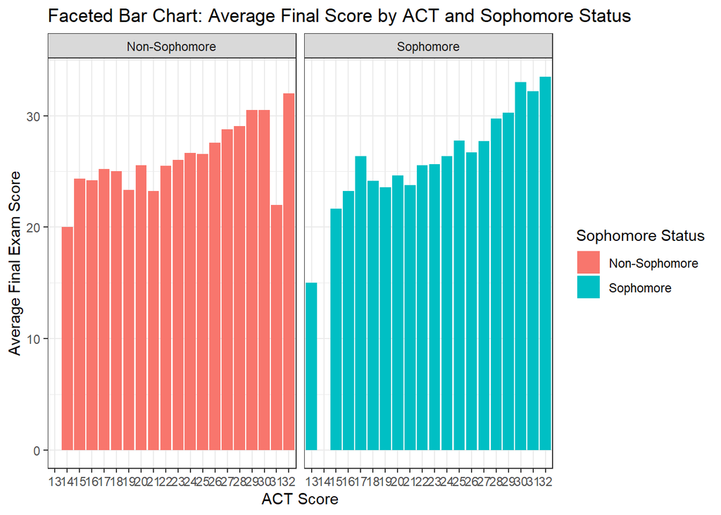

```r
ggplot(df_soph_relabeled_summarized, aes(x = factor(ACT), y = final_avg, fill = soph)) +
  geom_col() +
  facet_wrap(~ soph) +
  theme_bw() +
  labs(
    title = "Faceted Bar Chart: Average Final Score by ACT and Sophomore Status",
    x = "ACT Score",
    y = "Average Final Exam Score",
    fill = "Sophomore Status"
  )
```

## 4.2 4.2 Evaluation of the three charts

The dodged bar chart and faceted bar chart accurately describe the data better than the stacked bar chart. Since the y-axis shows average final exam score, it makes sense to compare the averages side by side or in separate panels. However, it doesn’t make sense to stack averages because adding average final exam scores together is not meaningful.

## 4.3 4.3 Compare Q3 dodged barplot with Q4 dodged barplot

I would trust the Q4 dodged barplot more than the Q3 dodged barplot. The Q3 version uses individual final scores in a way that can accidentally stack or combine observations. The Q4 version first summarizes the data by calculating the average final exam score for each ACT and sophomore-status group.

## 4.4 4.4 Differences in patterns between groups

The chart suggests that ACT score and final exam score are generally positively related, meaning students with higher ACT scores tend to have higher final exam scores. However, the pattern is not perfectly consistent, and some ACT score groups may have only a few students, causing the averages to fluctuate. There may also be some differences between sophomores and non-sophomores, but the bar chart alone does not provide enough evidence to draw a strong conclusion about those differences.

# 5 Ex 5: Boxplot vs. Correct Barplot

## 5.1 5.1 Boxplot of ACT score and final score grouped by sophomore status

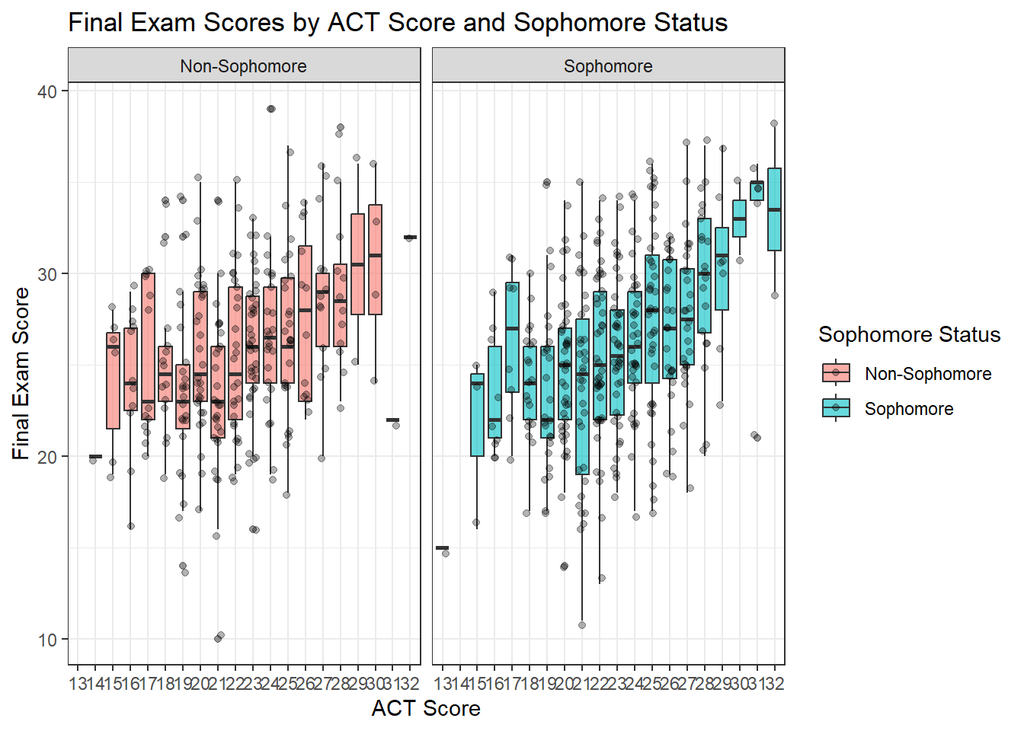

```r
ggplot(df_soph_relabeled, aes(x = factor(ACT), y = final, fill = soph)) +
  geom_boxplot(alpha = 0.6, outlier.alpha = 0.5) +
  geom_jitter(alpha = 0.3, width = 0.2) +
  facet_wrap(~ soph) +
  theme_bw() +
  labs(
    title = "Final Exam Scores by ACT Score and Sophomore Status",
    x = "ACT Score",
    y = "Final Exam Score",
    fill = "Sophomore Status"
  )
```

## 5.2 5.2 Boxplot compared with barplot

I prefer the boxplot because it shows more information than the barplot. The barplot focuses on averages, but the boxplot shows the median, spread, possible outliers, and the distribution of scores.

## 5.3 5.3 Relationship patterns by sophomore status

The boxplot suggests that final exam scores vary within each ACT score group. There may be a general tendency for higher ACT scores to be associated with higher final exam scores, but the relationship is not perfectly consistent. The sophomore and non-sophomore groups show some differences, but the variation within groups is also important.

# 6 Ex 6: Impact of ACT on Attendance, Moderated by Freshman Status: Boxplot

## 6.1 6.1 Boxplot using ACT and attendance grouped by freshman status

```r
df_frosh_relabeled <- df %>%
  mutate(
    frosh = case_when(
      frosh == 1 ~ "Freshman",
      frosh == 0 ~ "Non-Freshman"
    ),
    frosh = factor(frosh)
  )

df_frosh_relabeled
```

```
# A tibble: 680 × 11
   attend termGPA priGPA   ACT final atndrte hwrte frosh     soph missed stndfnl
    <int>   <dbl>  <dbl> <int> <int>   <dbl> <dbl> <fct>    <int>  <int>   <dbl>
 1     27    3.19   2.64    23    28    84.4 100   Non-Fre…     1      5  0.473
 2     22    2.73   3.52    25    26    68.8  87.5 Non-Fre…     0     10  0.0525
 3     30    3      2.46    24    30    93.8  87.5 Non-Fre…     0      2  0.893
 4     31    2.04   2.61    20    27    96.9 100   Non-Fre…     1      1  0.263
 5     32    3.68   3.32    23    34   100   100   Non-Fre…     1      0  1.73
 6     29    3.23   2.93    26    25    90.6 100   Non-Fre…     1      3 -0.158
 7     30    1.54   1.94    21    10    93.8  75   Freshman     0      2 -3.31
 8     26    2      2.12    22    34    81.2 100   Non-Fre…     1      6  1.73
 9     24    2.25   2.06    24    26    75   100   Freshman     0      8  0.0525
10     29    3      2.73    21    26    90.6 100   Non-Fre…     1      3  0.0525
# ℹ 670 more rows
```

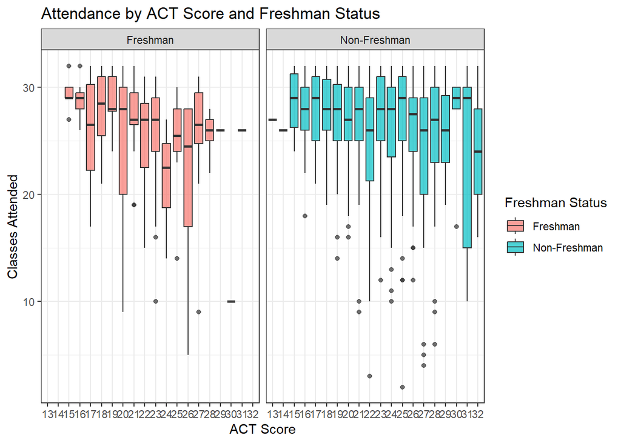

```r
ggplot(df_frosh_relabeled, aes(x = factor(ACT), y = attend, fill = frosh)) +
  geom_boxplot(alpha = 0.7) +
  facet_wrap(~ frosh) +
  theme_bw() +
  labs(
    title = "Attendance by ACT Score and Freshman Status",
    x = "ACT Score",
    y = "Classes Attended",
    fill = "Freshman Status"
  )
```

# 7 Ex 7: Attendance by ACT, Moderated by Freshman Status: Scatter Plot

## 7.1 7.1 Scatter plot with regression line

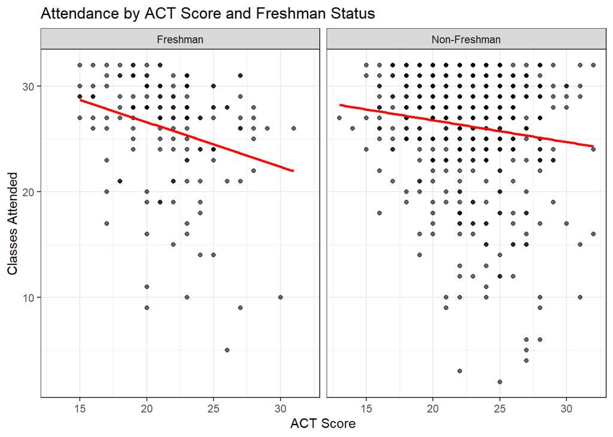

```r
ggplot(df_frosh_relabeled, aes(x = ACT, y = attend)) +
  geom_point(alpha = 0.6) +
  geom_smooth(method = "lm", se = FALSE, color = "red") +
  facet_wrap(~ frosh) +
  theme_bw() +
  labs(
    title = "Attendance by ACT Score and Freshman Status",
    x = "ACT Score",
    y = "Classes Attended"
  )
```

## 7.2 7.2 Summary of relationship

The scatter plot is useful because ACT is a continuous variable, so it doesn’t need to be converted into a factor. The regression lines make the group comparison clearer. Overall, the relationship between ACT and attendance appears to be modest. The pattern may differ somewhat between freshmen and non-freshmen, but the points show a lot of variation, so the relationship doesn’t look super strong.

# 8 Ex 8: Correlations

## 8.1 8.1 Correlation plots using ggpairs and ggcorr

```r
df_corr <- df %>%
  select(attend, termGPA, priGPA, ACT, final, atndrte, hwrte)

df_corr
```

```
# A tibble: 680 × 7
   attend termGPA priGPA   ACT final atndrte hwrte
    <int>   <dbl>  <dbl> <int> <int>   <dbl> <dbl>
 1     27    3.19   2.64    23    28    84.4 100
 2     22    2.73   3.52    25    26    68.8  87.5
 3     30    3      2.46    24    30    93.8  87.5
 4     31    2.04   2.61    20    27    96.9 100
 5     32    3.68   3.32    23    34   100   100
 6     29    3.23   2.93    26    25    90.6 100
 7     30    1.54   1.94    21    10    93.8  75
 8     26    2      2.12    22    34    81.2 100
 9     24    2.25   2.06    24    26    75   100
10     29    3      2.73    21    26    90.6 100
# ℹ 670 more rows
```

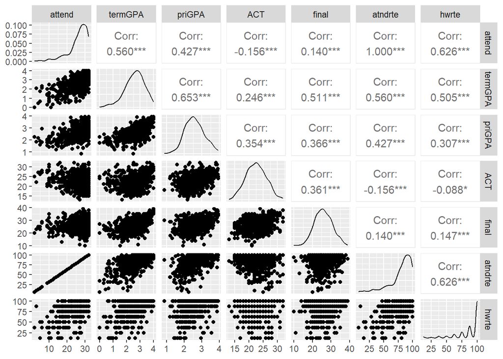

```r
ggpairs(df_corr)
```

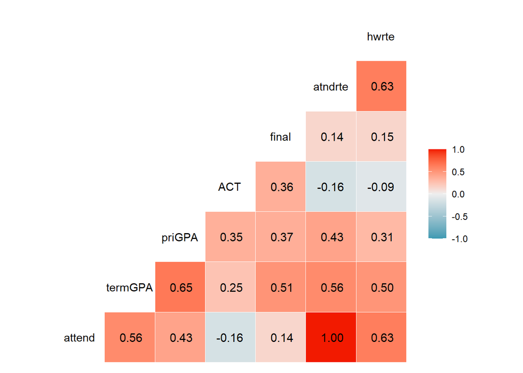

```r
ggcorr(df_corr, label = TRUE, label_round = 2)
```

```r
cor_matrix <- cor(df_corr, use = "complete.obs")

cor_matrix
```

```
            attend   termGPA    priGPA        ACT     final    atndrte
attend   1.0000000 0.5384264 0.4196933 -0.1336442 0.1480643  1.0000000
termGPA  0.5384264 1.0000000 0.6542621  0.2732598 0.5215440  0.5384264
priGPA   0.4196933 0.6542621 1.0000000  0.3681972 0.3710426  0.4196933
ACT     -0.1336442 0.2732598 0.3681972  1.0000000 0.3618229 -0.1336442
final    0.1480643 0.5215440 0.3710426  0.3618229 1.0000000  0.1480643
atndrte  1.0000000 0.5384264 0.4196933 -0.1336442 0.1480643  1.0000000
hwrte    0.6259695 0.5048751 0.3072889 -0.0884341 0.1465651  0.6259695
             hwrte
attend   0.6259695
termGPA  0.5048751
priGPA   0.3072889
ACT     -0.0884341
final    0.1465651
atndrte  0.6259695
hwrte    1.0000000
```

I like `ggpairs()` because it includes scatterplots, distributions, and correlation statistics which helps make things more detailed.

## 8.2 8.2 Highest positive correlation

```r
cor_long <- as.data.frame(as.table(cor_matrix)) %>%
  filter(Var1 != Var2) %>%
  mutate(pair = paste(Var1, Var2, sep = " - ")) %>%
  arrange(desc(Freq))

cor_long
```

```
      Var1    Var2       Freq              pair
1  atndrte  attend  1.0000000  atndrte - attend
2   attend atndrte  1.0000000  attend - atndrte
3   priGPA termGPA  0.6542621  priGPA - termGPA
4  termGPA  priGPA  0.6542621  termGPA - priGPA
5    hwrte atndrte  0.6259695   hwrte - atndrte
6  atndrte   hwrte  0.6259695   atndrte - hwrte
7    hwrte  attend  0.6259695    hwrte - attend
8   attend   hwrte  0.6259695    attend - hwrte
9  atndrte termGPA  0.5384264 atndrte - termGPA
10 termGPA atndrte  0.5384264 termGPA - atndrte
11 termGPA  attend  0.5384264  termGPA - attend
12  attend termGPA  0.5384264  attend - termGPA
13   final termGPA  0.5215440   final - termGPA
14 termGPA   final  0.5215440   termGPA - final
```

[output cut: 28 more lines]

# 9 Ex 9: Scatter Plot with Regression Line for priGPA and termGPA

## 9.1 9.1 Create scatter plot with separate regression lines by sophomore status

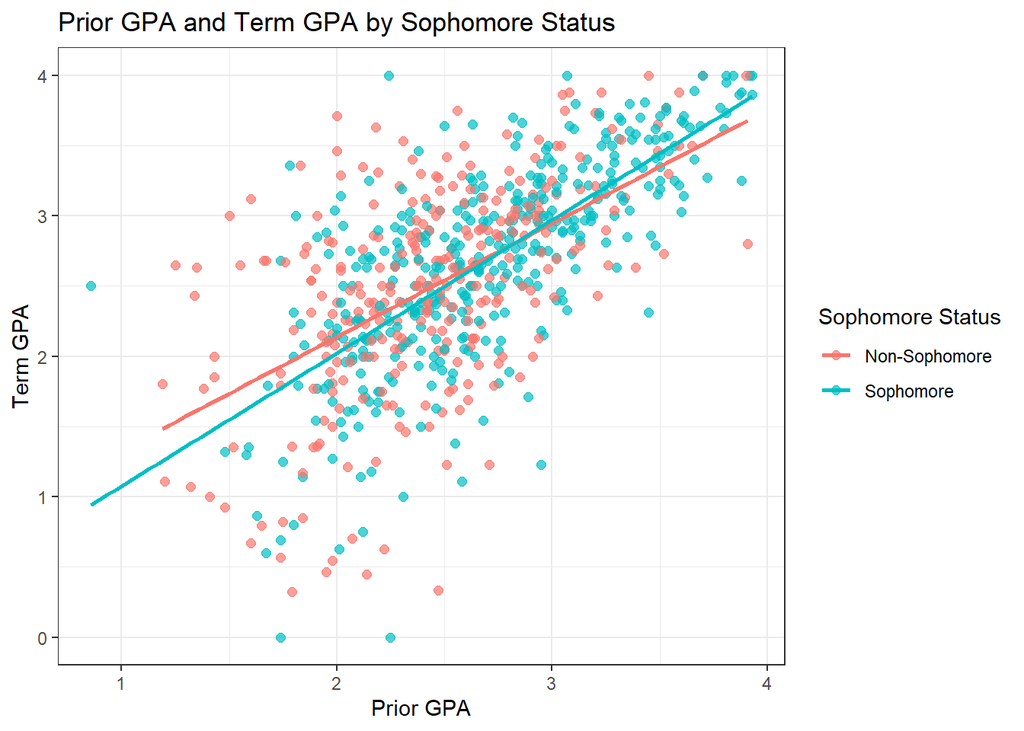

```r
plot <- ggplot(df_soph_relabeled, aes(x = priGPA, y = termGPA, color = soph)) +
  geom_point(size = 2, alpha = 0.7) +
  geom_smooth(method = "lm", se = FALSE) +
  theme_bw() +
  labs(
    title = "Prior GPA and Term GPA by Sophomore Status",
    x = "Prior GPA",
    y = "Term GPA",
    color = "Sophomore Status"
  )

plot
```

```r
ggsave("myplot.png", plot = plot)
```

```r
file.exists("myplot.png")
```

```
[1] TRUE
```

## 9.2 9.2 Relationship strength

The plot suggests a positive relationship between prior GPA and term GPA. Students with higher prior GPA generally tend to have higher term GPA. The separate regression lines allow us to compare whether this relationship is stronger or weaker for sophomores and non-sophomores. If one line is steeper, that group shows a stronger relationship between prior GPA and term GPA.

# 10 Ex 10: Interactive Plot and Save Plot

## 10.1 10.1 Interactive plot using ggplotly

```r
ggplotly(plot, tooltip = c("x", "y", "color"))
```

[interactive chart not shown]

The interactive plot allows the viewer to move the cursor over the points and see information from the chart. This makes it easier to explore the relationship between prior GPA and term GPA by sophomore status.

## 10.2 10.2 Save the plot as myplot.png

The plot from Ex 9 is saved as `myplot.png` in the project folder.